# Data Excerpts from the Human Rights Watch report “Get on the Ground!”: Policing, Poverty and Racial Inequality in Tulsa, Oklahoma

Brian Root

9/12/2019

# Introduction

This markdown document quotes text from the Human Rights Watch report ““Get on the Ground!”: Policing, Poverty and Racial Inequality in Tulsa, Oklahoma". The purpose of this document is to provide the source code to nearly every statistic that is included in the report. When viewing the tulsa_analysis_markdown.Rmd file, along with the original R scripts, the reader can determine how each statistic was computed.

# Chapter: Summary

### Page 6

“Our analysis of 2012-2017 data provided by the Tulsa Police Department, shows that black people in Tulsa are 2.7 times more likely to be subjected to physical force by police officers than white people on a per capita basis. Though only 17 percent of the population, black Tulsans were at the receiving end of 39 percent of police uses of force; white Tulsans, 65 percent of the population, only 55 percent.”

### Page 7

“According to data provided by the department, of the 1700 incidents and 3,364 distinct force actions reported by police from 2012 through 2017, the Tulsa Police Department found only two forceful acts that were not “within policy.”"

“Black people in Tulsa are also 2.3 times more likely than white people to be arrested on a citywide per capita basis. They are 17 percent of the population but make up 35 percent of all people arrested.”

“Though national studies show that drug use and sales are roughly the same across racial lines, Tulsa Police arrest black people 2.4 times more frequently than white people for drug crimes, and at substantially greater rates for marijuana.”

“Police arrest black people for warrants at a rate 2.6 times greater than white people, reflecting higher poverty rates among black people, but also suggesting possible bias in police investigative tactics.”

### Page 8

“One neighborhood in North Tulsa, defined as a census tract 62, 80 percent black with a low median income, experienced an annual average of 227 stops per 1,000 people from 2014 through 2017; in contrast, census tract 30 in West Tulsa, 77 percent white but also with a low median income, had a significantly lower stop rate of 50 per 1,000 people. And some well-to-do census tracts in South Tulsa, almost entirely white, had virtually no such stops by police: one experienced only 2 stops per 1,000 people over the same period, and another only 6 stops.”

### Page 9

“Black people are cited for violations at 1.4 times the rate of white people on a per capita basis.”

### Page 10

“From 2012 through 2017, in 38.4 percent of arrests, the most serious charge for which the person was arrested was a warrant: 20.7 percent from the county courts and 17.6 percent for municipal violations.”

# Chapter III. Deadly Force by Police

### Page 59

“Police made arrests in 12 of the incidents, according to the database.”

### Page 60

“Police were responding to “disturbance/weapon” calls in 11 instances; were making traffic stops in 7; investigating armed robberies in 6; serving warrants in 5; investigating auto thefts in 3; and stopping pedestrians in 2."

“In 29 percent of the 56 incidents, the person exposed to the use of deadly force was black, a high number compared to the 17 percent of Tulsa’s overall population that is black.”

# Chapter IV. Policing and Court Debt

### Page 65

“From 2012 through 2017, Tulsa Police made 115 arrests at this motel alone, according to Tulsa Police Department data. In this six-year stretch, there were almost no arrests for violent incidents. Over two-thirds of the arrests at the motel (70 percent) included a warrant, split roughly evenly between city and county warrants. Of those arrests for warrants, over 80 percent were only for warrants and not for any other violation.”

### Page 77

“Human Rights Watch analyzed Tulsa Police Department data from 2012 through 2017 and found that in almost four of every 10 arrests, the most serious arrest charge was a warrant, making warrants by far the most common reason for arrest. 20.7 percent of them were county-issued warrants and 17.6 percent municipal warrants. It was not possible to determine how many of these were for “failure to pay” costs, court fees, or fines. However, many county and city warrants relate to “failure to pay,” as evidenced by booking data cited previously. City warrants are for low-level misdemeanor charges or for citations, including basic traffic violations, and for “failure to pay” fees, fines and costs on those types of charges. In 33,721 of these arrests, the majority, a warrant was the only charge. There is no data to determine how many people arrested on these warrants were poor, but especially considering the prevalence of “failure to pay” warrants, it is likely that a large percentage were. Police arrest black people in Tulsa for warrants at a rate 2.6 times the rate that they arrest white people."

[interactive chart not shown]

# Chapter V. Arrests, Detentions, and Citations

### Page 85

Tulsa Police Department Arrests 2012 – 2017

| Race | Number of arrests | Percent of arrests | Percent of Tulsa population | Avg. annual arrest rate per 1,000 people |
| --- | --- | --- | --- | --- |
| Asian | 467 | 0.5% | 3.8% | 5.21 |
| Black | 33004 | 35.5% | 17.6% | 78.78 |
| Native American | 4478 | 4.8% | 8.3% | 22.56 |
| Unknown | 1339 | 1.4% | NA | NA |
| White | 53671 | 57.7% | 64.7% | 34.83 |

[interactive chart not shown]

### Page 90

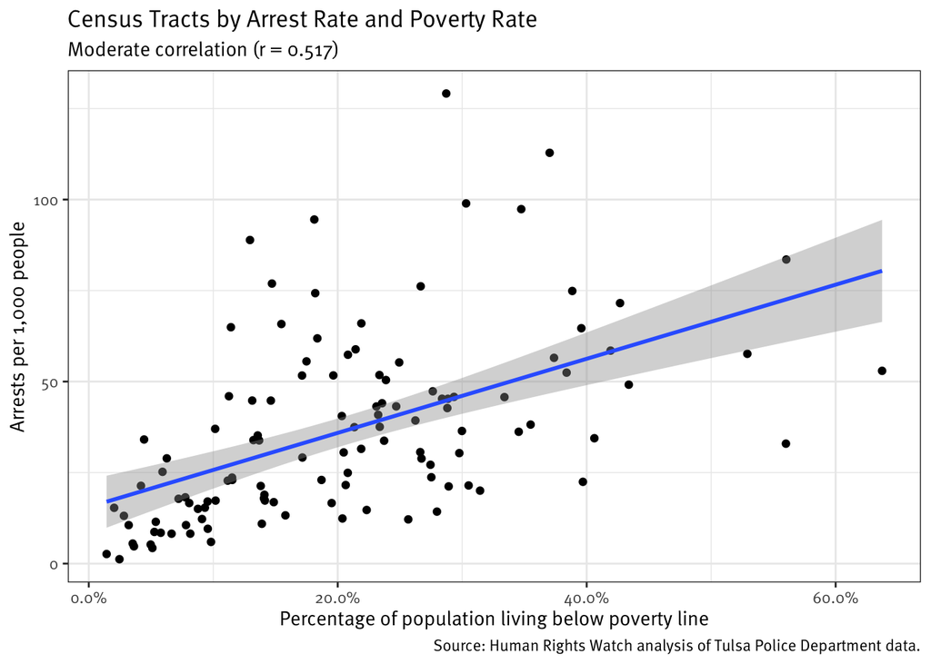

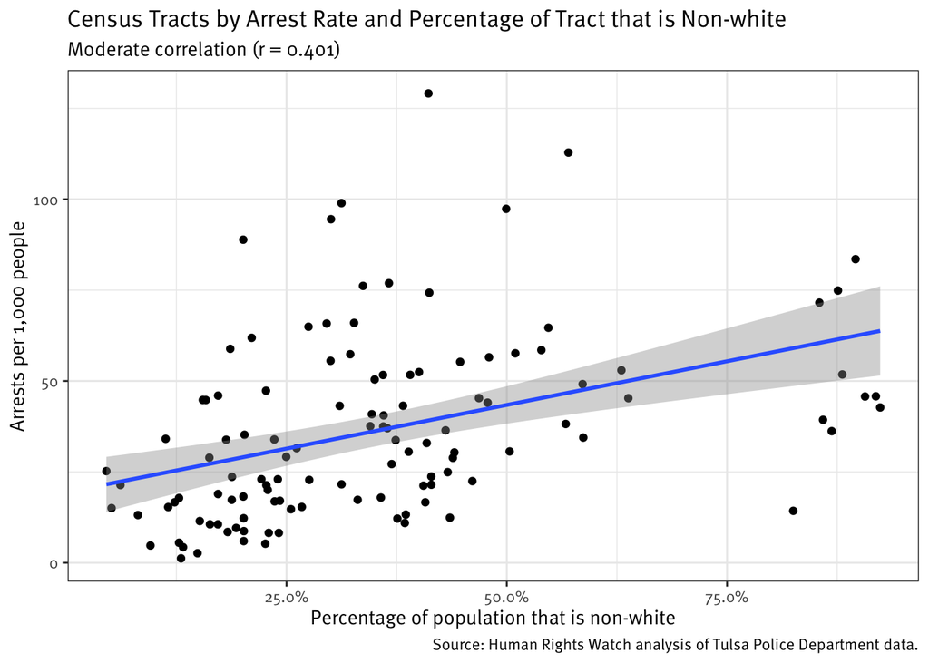

### Page 91

"The interplay between poverty, race, crime and policing are complex. To better understand its effects in Tulsa, Human Rights Watch analyzed the relationship between race-specific arrest rates and race-specific median household income using simple regression models. This analysis revealed that income has a much stronger relationship with arrest rates within the white population than it does for the black population. Arrest rates for black people have little relationship to the median income of black households within each census tract, while areas with higher household income for white people experience lower arrest rates for white people.

```
##
## Call:
## lm(formula = tract_race3$black_arrest_rate ~ tract_race3$median_black_income)
##
## Residuals:
##    Min     1Q Median     3Q    Max
## -67.74 -42.12 -17.70  12.72 453.40
##
## Coefficients:
##                                   Estimate Std. Error t value
## (Intercept)                     93.2805317 12.5570712   7.429
## tract_race3$median_black_income -0.0002504  0.0002788  -0.898
##                                        Pr(>|t|)
## (Intercept)                     0.0000000000636 ***
## tract_race3$median_black_income           0.372
## ---
## Signif. codes:  0 '***' 0.001 '**' 0.01 '*' 0.05 '.' 0.1 ' ' 1
##
## Residual standard error: 74.59 on 89 degrees of freedom
##   (21 observations deleted due to missingness)
## Multiple R-squared:  0.00898,    Adjusted R-squared:  -0.002155
## F-statistic: 0.8065 on 1 and 89 DF,  p-value: 0.3716
```

```
##
## Call:
## lm(formula = tract_race3$white_arrest_rate ~ tract_race3$median_white_income)
##
## Residuals:
##     Min      1Q  Median      3Q     Max
## -34.322 -16.890  -5.688  12.109  94.609
##
## Coefficients:
##                                    Estimate  Std. Error t value
## (Intercept)                     67.70699527  5.02690718  13.469
## tract_race3$median_white_income -0.00060983  0.00008927  -6.832
##                                             Pr(>|t|)
## (Intercept)                     < 0.0000000000000002 ***
## tract_race3$median_white_income       0.000000000501 ***
## ---
## Signif. codes:  0 '***' 0.001 '**' 0.01 '*' 0.05 '.' 0.1 ' ' 1
##
## Residual standard error: 23.63 on 109 degrees of freedom
##   (1 observation deleted due to missingness)
## Multiple R-squared:  0.2998, Adjusted R-squared:  0.2934
## F-statistic: 46.67 on 1 and 109 DF,  p-value: 0.0000000005009
```

### Page 92

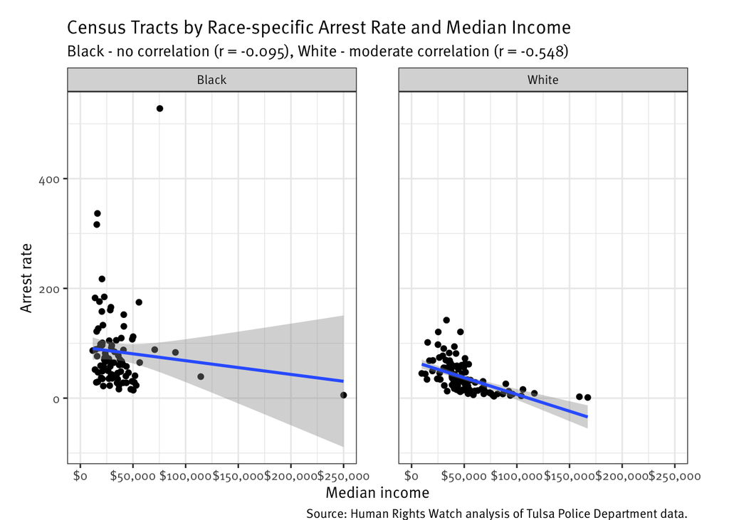

### Page 94

“While black people are 2.3 times more likely to be arrested than white people in Tulsa, in general, black people are 2.6 times more likely to be arrested for warrant charges.”

“Weapons offenses, also discovered primarily by police stops and searches as opposed to by police responding to calls, have high racial disparities, with black people arrested 4.3 times more frequently than white people.”

“Tulsa Police arrested black people for drug offenses at a rate 2.4 times greater than white people; marijuana possession, at a rate 4.3 times greater, though data indicates that rates of illegal drug use and sales are roughly even across racial groups and possibly higher for white people than black people nationwide.”

### Page 103

“Human Rights Watch requested detailed data on traffic and pedestrian stops by Tulsa Police, including the date, time, duration, reason for the stop, disposition of the stop, demographic description of the person stopped, and other information. Tulsa authorities responded with limited data about 157007 traffic stops and 19449 pedestrian stops that occurred from 2014 through 2017.”

### Page 104

“However, using the information available, Human Rights Watch was able to geocode 88 percent of them.”

### Page 105

[interactive chart not shown]

### Page 106

Traffic Stop Rates - Highest and Lowest Tracts

| Tract | Annual rate per 1K residents | Percent Black | Percent White | Median household income | Poverty rate |
| --- | --- | --- | --- | --- | --- |
| Census Tract 68.01 | 257 | 18% | 69% | 32861 | 30% |
| Census Tract 76.08 | 257 | 43% | 43% | 28309 | 37% |
| Census Tract 23.01 | 252 | 13% | 59% | 27563 | 29% |
| Census Tract 13 | 237 | 6% | 50% | 26813 | 35% |
| Census Tract 83 | 237 | 12% | 68% | 36875 | 22% |
| Census Tract 2 | 235 | 85% | 12% | 35714 | 23% |
| Census Tract 62 | 227 | 80% | 12% | 22788 | 39% |
| Census Tract 6 | 213 | 81% | 15% | 20927 | 43% |
| Census Tract 17 | 213 | 11% | 70% | 45129 | 17% |
| Census Tract 25 | 206 | 20% | 67% | 35938 | 29% |
| Census Tract 76.37 | 2 | 2% | 87% | 170278 | 2% |
| Census Tract 76.38 | 6 | 1% | 85% | 168194 | 1% |
| Census Tract 90.07 | 10 | 14% | 61% | 47191 | 16% |
| Census Tract 76.31 | 15 | 2% | 90% | 102500 | 4% |
| Census Tract 76.30 | 16 | 6% | 77% | 72500 | 5% |

### Page 108

Racial and Class Demographics of Areas Experiencing the Most and Least Traffic Stops

| Census Tract Traffic Stop Rate Quartiles | Total Population | Percent of Total Tulsa Population | Percent of Tulsa’s Black Population | Percent of Quartile Population that is Black | Percent of Quartile Population that is non-White | Average Tract Median Income | Average Tract Percentage Below Poverty Rate |
| --- | --- | --- | --- | --- | --- | --- | --- |
| Lowest rate of traffic stops | 114299 | 30% | 23% | 13% | 30% | 63243 | 17% |
| Second quartile | 96065 | 25% | 16% | 11% | 29% | 56802 | 17% |
| Third quartile | 88411 | 23% | 32% | 23% | 42% | 41895 | 23% |
| Highest rate of traffic stops | 82576 | 22% | 29% | 22% | 43% | 36980 | 25% |

### Page 109

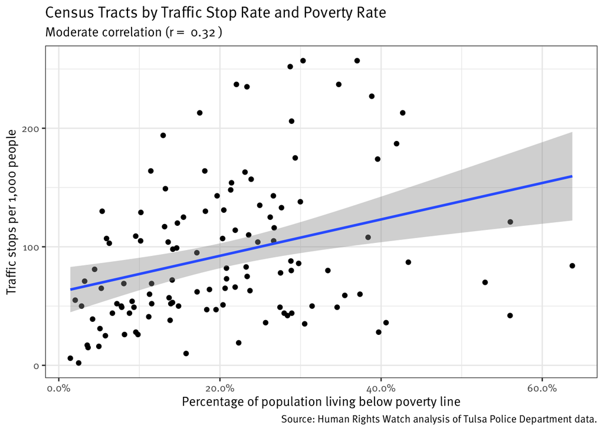

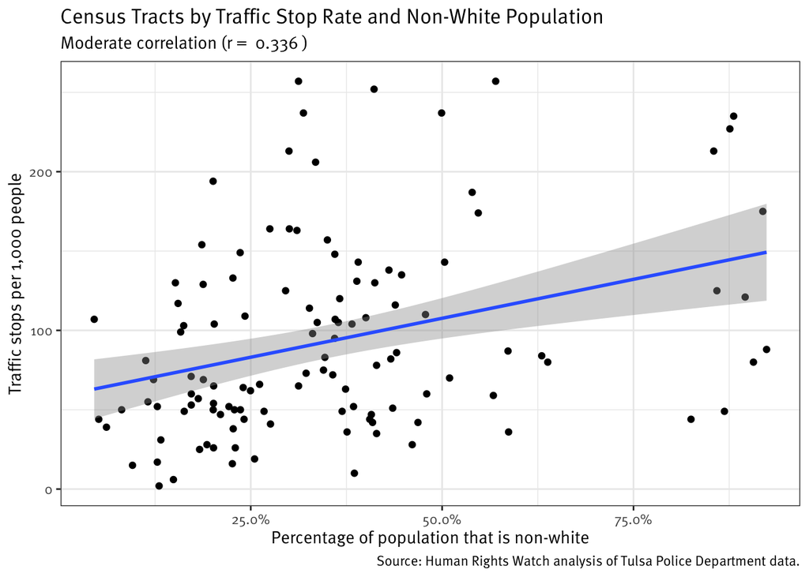

### Page 114

“Human Rights Watch found a strong correlation (r = 0.532) between the average length of a traffic stop in a given census tract and the percentage of its residents below the poverty line. Length of traffic stops also correlated (r = 0.476) with the percentage of the population that is non-white.”

“The longest stops were most concentrated in North Tulsa. For example, Tract 5, just east of Peoria, between Pine and Apache (90 percent non-white; 56 percent living below the poverty line), and Tract 79, west of Peoria and North of 46th Street, (91 percent non-white; 33 percent living below the poverty line) had average stop times of 42 and 44 minutes, respectively. Tract 76.19, in South Tulsa, west of South Memorial Drive between E. 81st Street and E. 71st Street, which is 15 percent non-white and has 5 percent living below the poverty line, had an average stop time of only 20 minutes.”

### Page 115

[interactive chart not shown]

### Page 118

“There is a racial disparity in ticketing patterns, though not as severe as the disparity in arrests and uses of force. Black people are about 17 percent of Tulsa’s population, but they receive 25 percent of the citations, and are cited at an average annual rate of 880 per 1,000, a rate 1.4 times higher than the rate for white people.”

### Page 120

“The rates of violations related to observable driving behavior, like speeding, are roughly even between black and white Tulsans. However, there are significant disparities for license/insurance violations, which are likely to be more prevalent in poorer and more heavily policed areas because they often stem from previous arrests and inability to pay premiums. Black people received these types of citations at a rate 2.2 times higher than white people.”

Proportion of Population and Citations by Race (2016-17

| Group | Black | White |
| --- | --- | --- |
| Tulsa population | 18% | 65% |
| Speeding | 18% | 76% |
| Driver’s license/liability insurance related | 35% | 59% |

### Page 121

Proportion of Citation Types (2016-17

| Citation | Tulsa total | North Tulsa | Non-North Tulsa | Top 3 locations | Top 10 officers |
| --- | --- | --- | --- | --- | --- |
| Speeding | 32% | 18% | 35% | 68% | 50% |
| Driver’s license/liability insurance related | 28% | 40% | 26% | 20% | 26% |
| Seatbelt | 7% | 13% | 6% | 7% | 11% |
| License plate related | 11% | 10% | 12% | 5% | 8% |
| Non-moving violation | 2% | 2% | 2% | 0% | 1% |
| Moving violation (non-speeding) | 12% | 10% | 12% | 0% | 4% |
| Other violation | 3% | 2% | 3% | 0% | 0% |

# Chapter VI. Police Violence

### Page 127

"This dataset included 1700 incidents involving less lethal force between 2012 and 2017, which included 3364 distinct force actions. The number of incidents generally remained steady over time, with an average of 23 per month.

“Electronic control devices,” often referred to as “Tasers,” were the most common type of non-deadly force used, accounting for nearly one-fifth of the total. “Physical control holds” made up 15 percent; pepper-spray, 13 percent; and dog bites, 12 percent. The rest was made up of various types of punches, kicks, and knee strikes, and use of other weapons, such as batons and pepper-ball launchers."

### Page 128

“Tulsa Police reported injuries to the civilians subjected to use of force in 46 percent of the incidents, and injuries to officers in 8 percent. They did not distinguish severity of the injuries in the data provided, so these percentages reveal little.”

“Force incidents occurred across a broad range of types of police encounters or activities. The most common were investigations of domestic assaults or disturbances (12 percent of incidents), “other disturbances” (11 percent), burglary investigations (10 percent), traffic stops (8 percent), warrant service (7 percent), and pedestrian checks (5 percent). In 66 percent of all incidents Tulsa police gave “resisting” as the justification for the police use of physical force. In 13 percent, the justification was “eluding.” Neither term is clearly defined. In 3 percent of use-of-force incidents, Tulsa police claimed an assault or battery on an officer as justification for police use of less lethal force.

In 90 percent of the incidents provided by the Tulsa Police Department, officers arrested the person. Though the dataset of the 1700 incidents did not include information to directly evaluate these arrests, Human Rights Watch was able to use street names and times of arrest to match 648 of them with more detailed information from an arrest dataset. Using this information, we found that the most common arrest offenses in these use of force cases tended not to be violent charges. In 21 percent of the arrests, the most serious charge was some form of “disorderly conduct;” assault on an officer, 14 percent; public intoxication accounted for 11 percent; weapons possession, 7 percent; other assault, about 6 percent."

### Page 129

“According to the data Tulsa police provided to Human Rights Watch, the rate with which police use physical force against black people in Tulsa is 2.7 times greater than the rate used against white people on a per capita basis. There were 1.6 documented incidents per 1,000 black residents per year during this time period as compared to 0.6 per 1,000 white people. While making up about 17 percent of Tulsa’s population, black people are subject to almost 39 percent of police violence.”

### Page 130

Tulsa Police Department Use of Force Incidents 2012 – 2017

| Race | Use of force incidents | Percent of use of force incidents | Percent of Tulsa population | Rate of force per 1,000 arrests | Rate of force per 1,000 residents per year | Number of arrests per use of force incident |
| --- | --- | --- | --- | --- | --- | --- |
| Black | 670 | 39% | 18% | 20.30 | 1.60 | 49 |
| Native American | 69 | 4% | 8% | 15.41 | 0.35 | 65 |
| Unknown | 32 | 2% | NA% | 23.90 | NA | 42 |
| White | 929 | 55% | 65% | 17.31 | 0.60 | 58 |

“Tulsa Police redacted addresses in the data, but they did give zip codes for 75 percent of incidents from 2016 and 2017, the last two years for which data was provided. Using census data to calculate rates of force used within each zip code, Human Rights Watch found that areas with higher percentages of non-white people correlated to higher rates of police violence.”

### Page 131

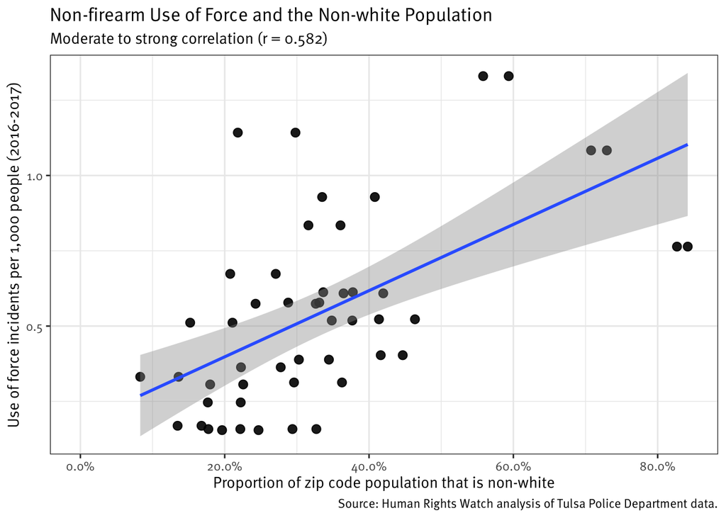

“Racial disparities are reflected in the types of use of force. Police used pepper-spray on black people at 3.6 times the rate they used it on white people on a per capita basis. They used tasers on black people 2.9 times as frequently, and they ordered police dogs to bite them 2.1 times as often.” (footnote: The racial disparities persist to a lesser degree when looking at rates of use per arrest. Tasers were used 1.3 times more often per arrest of black people than white people and pepper spray 1.6 times more often. K-9’s are used slightly more (0.9) often per arrest of white people than of black arrestees.)

“Human Rights Watch analyzed how often force is used per arrest by calculating rates of force used per 1,000 arrests. While the disparity in force used per arrest is lower than force used per capita, black arrestees were subjected to force at a rate 17 percent higher than white arrestees.”

### Page 134

“Of 3364 separate acts of “non-deadly” force in 1700 incidents reported by the Tulsa Police Department for the 2012-2017 period, authorities concluded that only two were “out of policy.” The data the department provided indicates that neither of the two resulted in disciplinary action."

### Page 135

“The force incident data provided to Human Rights Watch documents that between 2012 and 2017, there were 333 police dog bite incidents, nearly one every six days, almost all of which were reported to have caused injury. These figures accounted for one quarter of all injuries to civilians reported by the department. Canine bites were used on black people at 2.1 the per capita rate they were used on white people.”

### Page 136

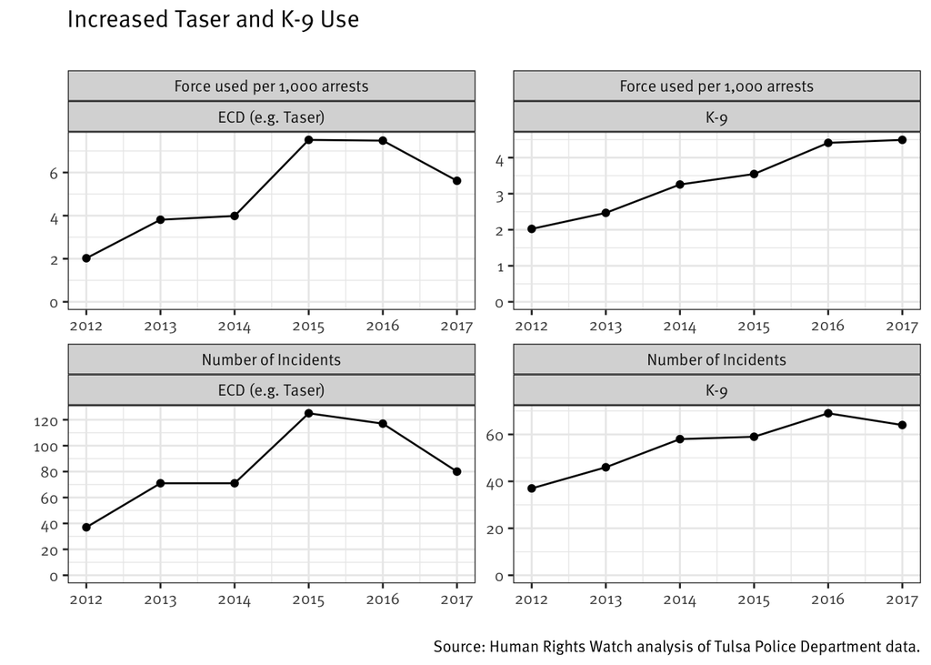

### Page 139

# Chapter VIII. Tulsa Police and the Latino Immigrant Community